# Ass4

# QUESTION 8

## a

For h0 there is no significant differences between the variances at each site.

H0 = sigma^2 = sigma2^2

For h1 there is a significant difference between both site variances.

H1 = opposite of null

## b

```r
gob = read.csv("GOBIANTS.csv")

head(gob)
```

```
##   Site      Region Rain Temp PlantCov AntSpecies Diversity
## 1    1  Dry Steppe  196  5.7       40          3      0.89
## 2    2  Dry Steppe  196  5.7       52          3      0.83
## 3    3  Dry Steppe  179  7.0       40         52      1.31
## 4    4  Dry Steppe  197  8.0       43          7      1.48
## 5    5  Dry Steppe  149  8.5       27          5      0.97
## 6    6 Gobi Desert  112 10.7       30         49      0.46
```

F=S21/S22 so F=1.0498

## c

The rejection region is where $F > F_{\alpha/2}$,  
$F_{\alpha/2}$ being where x numerator and $x_2$ are the degrees of freedom for the numerator and denominator sample variances.

Since alpha is .5, alpha/2 is .025.

$F_{0.025} (25.25) = 2.23$ so $H_0$ is rejected when F exceeds 2.23.

## d

F was found to be 1.0498.

So the P value

$P(F<1.0498) = .55$

$P(F>= 1.0498) = 1 -.55 = .45$

$ P = 2 *.45 = .9 $

## e

.05 is less than the P value of .9. This is not in the rejection region so we cannot reject the hypothesis. With 95% confidence we can say there is no significant difference between two variances at the sites.

## f

The P value needs to be less than .05 for this to be true.

# QUESTION 9

The Null hypthesis is $\mu = 0$ and alternative is !=0

```r
data<- read.csv("THRUPUT.csv")

t.test(data$HUMAN, data$AUTO, mu=0, paired = T)
```

```
##
##  Paired t-test
##
## data:  data$HUMAN and data$AUTO
## t = -2.629, df = 7, p-value = 0.03396
## alternative hypothesis: true difference in means is not equal to 0
## 95 percent confidence interval:
##  -61.850346  -3.274654
## sample estimates:
## mean of the differences
##                -32.5625
```

# QUESTION 10

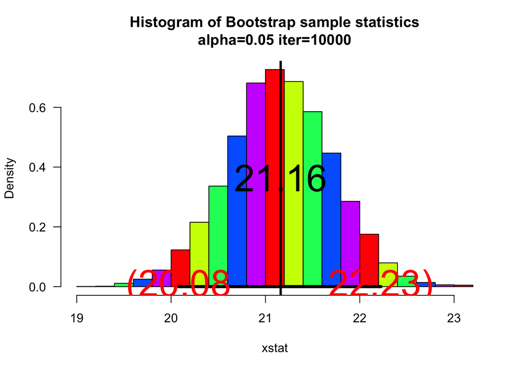

```
## $ci
##     2.5%    97.5%
## 20.07910 22.22545
##
## $fun
## [1] "mean"
##
## $x
##  [1] 23.195 20.399 19.898 19.865 30.014 18.821 21.232 18.313 23.574 21.047
## [11] 21.535 21.336 17.695 18.497 14.274 14.664 22.593 18.963 25.515 25.019
## [21] 22.053 22.871 23.006 23.829 19.038 21.735 21.461 21.659 21.703 21.049
##
## $t
## function (x)
## UseMethod("t")
## <bytecode: 0x118d0b908>
## <environment: namespace:base>
```

```r
## sample function
set.seed(35) # This will give everyone the same sample
sam=round(rnorm(30,mean=20,sd=3),3)



########### bootstrap function ##################

myboot<-function(iter=10000,x,fun="mean",alpha=0.05,...){  #Notice where the ... is repeated in the code
n=length(x)   #sample size

y=sample(x,n*iter,replace=TRUE)
rs.mat=matrix(y,nr=n,nc=iter,byrow=TRUE)
xstat=apply(rs.mat,2,fun) # xstat is a vector and will have iter values in it
ci=quantile(xstat,c(alpha/2,1-alpha/2))# Nice way to form a confidence interval
# A histogram follows
# The object para will contain the parameters used to make the histogram
para=hist(xstat,freq=FALSE,las=1,
main=paste("Histogram of Bootstrap sample statistics","\n","alpha=",alpha," iter=",iter,sep=""),
...,col = rainbow(5))

#mat will be a matrix that contains the data, this is done so that I can use apply()
mat=matrix(x,nr=length(x),nc=1,byrow=TRUE)

#pte is the point estimate
#This uses whatever fun is
pte=apply(mat,2,fun)
abline(v=pte,lwd=3,col="Black")# Vertical line
segments(ci[1],0,ci[2],0,lwd=4)      #Make the segment for the ci
text(ci[1],0,paste("(",round(ci[1],2),sep=""),col="Red",cex=3)
text(ci[2],0,paste(round(ci[2],2),")",sep=""),col="Red",cex=3)

# plot the point estimate 1/2 way up the density
text(pte,max(para$density)/2,round(pte,2),cex=3)

return(list(ci=ci,fun=fun,x=x, t=t))# Some output to use if necessary
}
myboot(x=sam)
```